# Two Six Capital Data Challenge

This is a project that I completed as a part of my application for an internship at Two Six Capital. This notebook contains the original work that I did, but you can view the finished product, as well as the detailed instructions, on this project's [GitHub page](https://github.com/chrispyles/two-six-capital-challenge). The basis of the challange was to use a provided data set over transactions from one of Two Six Capital's businesses and answer four questions about the business:

- Is the business improving or deteriorating?
- Are there regional differences in the business?
- Is there seasonality in customer behavior?
- Is customer quality getting better or worse over time?

Below, you can find the original code that I wrote to answer these questions, as well as the graphics that I createde with `matplotlib`. The graphics you see in the report were made using Google Sheets. I recommend reviewing the `code.py` file in the GitHub repository, as it is the finished product. This notebook is a "rough draft" of the code, with some explanations added in later.

## 1. Import Modules and Set matplotlib Settings

For this project, I used the UC Berkeley `datascience` library, as well as NumPy, Pandas, Itertools, and matplotlib. The cell below also sets some pertinent settings to use matplotlib in this notebook. The cell below that imports the csv file containing the original data set as a `datascience` Table object.

```python
from datascience import *
import numpy as np
import pandas as pd
from itertools import combinations

import matplotlib
%matplotlib inline
import matplotlib.pyplot as plt
plt.style.use('ggplot')
import warnings
warnings.simplefilter('ignore', FutureWarning)
```

```python
data = Table.read_table('data.csv')
data
```

| user | transaction_date | sales_amount | join_date | region |
| --- | --- | --- | --- | --- |
| 665 | 1/2/13 | 31.77 | 2/8/11 | E |
| 598 | 1/2/13 | 6.2 | 7/30/09 | I |
| 26 | 1/2/13 | 35.03 | 6/18/03 | B |
| 1358 | 1/2/13 | 32.73 | 1/2/13 | K |
| 671 | 1/2/13 | 3.64 | 5/27/08 | E |
| 498 | 1/2/13 | 11.98 | 3/5/03 | D |
| 4 | 1/2/13 | 73.91 | 7/28/11 | B |
| 651 | 1/2/13 | 4.05 | 6/13/11 | H |
| 1648 | 1/2/13 | 20.09 | 11/25/09 | B |
| 1941 | 1/2/13 | 41.74 | 5/8/11 | M |

... (51465 rows omitted)

### A Note About the Data Set

Some aspects of the data set are skewed and so conclusions can't be drawn based on them. For example, the data set has a row for each transaction that took place from Jan 2013 to Apr 2016. However, it includes a `join_date` column. But what if someone joined before Jan 2013 and had no transactions during the interval of the data? It is important that we do not let survivor bias cloud the results, so I will ignore the `join_date` column for most of the analysis.

## 2. Useful Functions and Data Cleaning

In this section, I defined two useful functions, `repeat` and `not_nan`, which are used later in the project. I also defined functions to clean the data set. What they do, ultimately, is remove any rows with dates that are `nan` values and reformat the string MM/DD/YY dates to integers in YYYYMMDD format, so they can be compared with numerical operators.

```python
def repeat(x, n):
    return [x for i in range(n)]

def not_nan(string):
    return string != 'nan'

def clean_date(string):
    date = string.split('/')
    if int(date[2]) > 18:
        year = '19' + date[2]
    else:
        year = '20' + date[2]
    if len(date[0]) == 1:
        month = '0' + date[0]
    else:
        month = date[0]
    if len(date[1]) == 1:
        day = '0' + date[1]
    else:
        day = date[1]
    return int(year + month + day)

def clean_table_dates(table, column):
    cleaned_dates = table.apply(clean_date, column)
    return table.drop(column).with_column(column, cleaned_dates)

def clean_data():
    # exclude where transaction date is 'nan'
    data1 = data.where('transaction_date', not_nan)
    tx_dates = clean_table_dates(data1, 'transaction_date')

    # exclude where join date is 'nan'
    tx_dates_not_nan = tx_dates.where('join_date', not_nan)
    all_dates_clean = clean_table_dates(tx_dates_not_nan, 'join_date')

    return all_dates_clean
```

```python
cleaned_data = clean_data()
cleaned_data.sort('join_date', descending=True)
```

| user | sales_amount | region | transaction_date | join_date |
| --- | --- | --- | --- | --- |
| 8868 | 6.63 | C | 20131021 | 20160530 |
| 9691 | 17.21 | H | 20160430 | 20160430 |
| 9661 | 12.29 | E | 20160430 | 20160430 |
| 8342 | 43.79 | P | 20160430 | 20160430 |
| 6770 | 58.12 | C | 20160430 | 20160430 |
| 2930 | 35.43 | B | 20160430 | 20160430 |
| 9843 | 37.96 | F | 20160429 | 20160429 |
| 9262 | 72.87 | I | 20160429 | 20160429 |
| 8123 | 60.6 | L | 20160429 | 20160429 |
| 7960 | 46.55 | A | 20160429 | 20160429 |

... (51454 rows omitted)

Just to make sure that I'm not excluding too much of the data, I calculated the percentage of rows that were excluded by removing rows with dates that are `nan`. The cell below shows that only about 0.02% of the rows were excluded, so it's safe to say that we're OK to draw conclusions based on the clean data set.

```python
number_wo_join_date = data.where('join_date', lambda x: not not_nan(x)).num_rows
number_w_join_date = data.where('join_date', not_nan)
number_wo_transaction_date = number_w_join_date.where('transaction_date', lambda x: not not_nan(x)).num_rows
(number_wo_join_date + number_wo_transaction_date)/data.num_rows
```

```
0.00021369596891694997
```

## 3. A/B Test on Different Regions

In order to answer the second question, I decided to construct the framework to run A/B tests on each pair of regions to determine whether or not regionality exists in the data. My null and alternative hypotheses were:

- **Null Hypothesis:** There is no difference between the two regions. Any difference in the observed data is due to random chance.
- **Alternative Hypothesis:** Regionality exists in the data; that is, differences between regions are due to some factor other than random chance.

I decided to use the absolute difference between the mean number of transactions per year between the two regions as my test statistic. Here is the basic algorithm for the A/B test, which spans several code cells below:

1. Choose two regions, R1 and R2, and then select the rows of the `cleaned_data` table where the region is R1 or R2.
2. Randomly assign either R1 or R2 to each of the rows, regardless of their original designation. This means that the number of rows stays the same, but the ratio of R1 to R2 rows changes.
3. Compute the mean number of transactions per year by dividing the number of rows for R1 and R2 by 4.
4. Find the absolute different between the mean for R1 and R2
5. Run steps 2-4 over and over, collecting the result of the shuffle in an array.
6. Find the proportion of results in the array that are *greater than or equal to* the value of the test statistic *for the original distribution*. This is the p-value.
7. If the p-value is 0.05 or less, conclude in the direction of the alternative hypothesis. Otherwise, conclude in the direction of the null hypothesis.

Here is some information from the docstrings on the functions defined below:

- `avg_counts`: Groups rows of table by region and finds the average number of transactions per region per year; output is a table with columns `'region'` and `'avg'`
- `compute_ts_for_regions`: Computes the test statistic for two regions in the cleaned_data table, either with shuffling or without (in the case of the original test statistic)
- `ab_test`: Performs an A/B Test on two regions and returns the p-value
- `run_ab_tests`: Runs the A/B Test on all possible combinations of regions A thru U

```python
def avg_counts(table, column):
    grouped = table.group(column)
    ts_for_region = grouped.apply(lambda x: x/4, 'count')
    return grouped.drop('count').with_column('avg', ts_for_region)

original_ts = avg_counts(cleaned_data, 'region')
original_ts.show()
```

| region | avg |
| --- | --- |
| A | 547 |
| B | 2285.75 |
| C | 2403.75 |
| D | 668.75 |
| E | 352.5 |
| F | 354.5 |
| G | 1319 |
| H | 686.5 |
| I | 1280.5 |
| J | 146.25 |
| K | 103.25 |
| L | 395.25 |
| M | 693.5 |
| N | 276.25 |
| O | 289.25 |
| P | 493 |
| Q | 51 |
| R | 11.75 |
| S | 406 |
| T | 79.75 |
| U | 22.5 |

```python
def compute_ts_for_regions(r1, r2, shuffle=True):
    if shuffle:
        regions = cleaned_data.where('region', are.contained_in(make_array(r1, r2))).select('region')
        shuffled = np.random.choice(make_array(r1, r2), regions.num_rows)
        regions = regions.with_column('shuffled_region', shuffled).drop('region')

        # compute test statistics
        t = avg_counts(regions, 'shuffled_region')

        shuffled_dif = abs(t.column('avg').item(0) - t.column('avg').item(1))

        return shuffled_dif
    else:
        regions = cleaned_data.where('region', are.contained_in(make_array(r1, r2))).select('region')

        # compute test statistics
        t = avg_counts(regions, 'region')

        original_dif = abs(t.column('avg').item(0) - t.column('avg').item(1))

        return original_dif
```

```python
# testing the function
compute_ts_for_regions('A', 'B')
```

```
18.25
```

```python
def ab_test(r1, r2, reps):
    test_stats = make_array()
    original_ts = compute_ts_for_regions(r1, r2, shuffle=False)

    for i in np.arange(reps):
        stat = compute_ts_for_regions(r1, r2)
        test_stats = np.append(test_stats, stat)

    return np.count_nonzero(test_stats >= original_ts) / len(test_stats)
```

```python
def run_ab_tests(reps):
    regions = list('ABCDEFGHIJKLMNOPQRSTU')
    pairs = list(combinations(regions, 2))

    results = []
    for pair in pairs:
        p_val = ab_test(pair[0], pair[1], reps)
        results += [[pair, p_val]]

    tbl = Table().with_columns(
        'Region 1', [i[0][0] for i in results],
        'Region 2', [i[0][1] for i in results],
        'P-Value', [i[1] for i in results])
    return tbl
```

## 4. Finding an Alternative to `run_ab_tests`

Because the `run_ab_tests` function takes too long to run on my computer, I decided to select some regions that would give good information without running the A/B test on all 210 combinations. The functions define below have the ultimate effect of choosing 18 region pairs (6 with a low (< 100) value of the test statistic, 6 with a medium (between 100 and 1000) value, and 6 with a high (> 1000) value) and computing the p-values for those pairs of regions.

Here is some information on the functions below from their docstrings:

- `find_original_ts`: Returns a table with each possible pair of regions and the value of the test statistic for that pair; returns a table with three columns: `'Region 1'`, `'Region 2'`, `'Test Statistic'`
- `select_hi_mid_low`: Selects pairs of regions based on whether or not their original test statistic value is high or low on a logarithmic scale
- `run_select_ab_tests`: Runs the A/B Test on the pairs of regions chosen in the select_hi_mid_low function; returns a table with five columns: `'Region 1'`, `'Region 2'`, `'Original Test Stat'`, `'Category'`, `'P-Value'`

```python
def find_original_ts():
    regions = list('ABCDEFGHIJKLMNOPQRSTU')
    pairs = list(combinations(regions, 2))

    results = []
    for pair in pairs:
        ts = compute_ts_for_regions(pair[0], pair[1], shuffle=False)
        results += [[pair, ts]]

    tbl = Table().with_columns(
        'Region 1', [i[0][0] for i in results],
        'Region 2', [i[0][1] for i in results],
        'Test Statistic', [i[1] for i in results])
    return tbl
```

```python
original_test_stats = find_original_ts()
original_test_stats
```

| Region 1 | Region 2 | Test Statistic |
| --- | --- | --- |
| A | B | 1738.75 |
| A | C | 1856.75 |
| A | D | 121.75 |
| A | E | 194.5 |
| A | F | 192.5 |
| A | G | 772 |
| A | H | 139.5 |
| A | I | 733.5 |
| A | J | 400.75 |
| A | K | 443.75 |

... (200 rows omitted)

```python
def select_hi_mid_low():
    low = original_test_stats.where('Test Statistic', are.below(100)).sample(6)
    mid = original_test_stats.where('Test Statistic', are.between(100, 1000)).sample(6)
    hi = original_test_stats.where('Test Statistic', are.above(1000)).sample(6)

    sets_of_pairs = []
    for i in [low, mid, hi]:
        for j in np.arange(6):
            sets_of_pairs += [[i.row(j)[0], i.row(j)[1]]]

    return sets_of_pairs[0:7], sets_of_pairs[7:13], sets_of_pairs[13:]


low_ts_pairs, mid_ts_pairs, hi_ts_pairs = select_hi_mid_low()

def run_select_ab_tests():
    results = []
    for i in low_ts_pairs:
        result = ab_test(i[0], i[1], 1000)
        results += [[i, result]]

    for i in mid_ts_pairs:
        result = ab_test(i[0], i[1], 1000)
        results += [[i, result]]

    for i in hi_ts_pairs:
        result = ab_test(i[0], i[1], 1000)
        results += [[i, result]]

    original_stats = [original_test_stats.where('Region 1', i[0][0]).where('Region 2', i[0][1]).column('Test Statistic').item(0) for i in results]

    t = Table().with_columns(
        'Region 1', [i[0][0] for i in results],
        'Region 2', [i[0][1] for i in results],
        'Original Test Stat', original_stats,
        'Category', repeat('Low', 6) + repeat('Medium', 6) + repeat('High', 6),
        'P-Value', [i[1] for i in results])
    return t
```

```python
selected_p_vals = run_select_ab_tests()
```

```python
selected_p_vals.show()
```

| Region 1 | Region 2 | Original Test Stat | Category | P-Value |
| --- | --- | --- | --- | --- |
| F | O | 65.25 | Low | 0 |
| G | I | 38.5 | Low | 0.123 |
| J | Q | 95.25 | Low | 0 |
| Q | R | 39.25 | Low | 0 |
| E | S | 53.5 | Low | 0 |
| E | F | 2 | Low | 0.894 |
| L | O | 106 | Medium | 0 |
| M | U | 671 | Medium | 0 |
| F | J | 208.25 | Medium | 0 |
| D | K | 565.5 | Medium | 0 |
| M | Q | 642.5 | Medium | 0 |
| J | P | 346.75 | Medium | 0 |
| C | U | 2381.25 | High | 0 |
| G | T | 1239.25 | High | 0 |
| C | Q | 2352.75 | High | 0 |
| B | S | 1879.75 | High | 0 |
| B | S | 1879.75 | High | 0 |
| C | D | 1735 | High | 0 |

## 5. Determining Seasonality in Customer Behavior

To start answering the third question, I defined some useful functions that convert the integer YYYYMMDD dates into strings with the season and year. I exported two tables, `seasons_by_year` and `users` as csv files to make graphics in Sheets. The `seasons_by_year` table has the transaction dates replaced with season-year strings (e.g. `20181018` would become `'Fall 2018'`). The `users` table has the transaction dates replaced with month-year strings (e.g. `20181018` would become `'Oct 2018'`).

```python
def get_month(d):
    d = d//100
    d = d % 100
    return d

def month_to_string(d):
    d = get_month(d)
    months = ['Jan', 'Feb', 'Mar', 'Apr', 'May', 'Jun',
             'Jul', 'Aug', 'Sep', 'Oct', 'Nov', 'Dec']
    return months[d-1]

def get_year(d):
    return d // 10000

def get_season(d):
    month = get_month(d)
    if month in [12, 1, 2]:
        return 'Winter'
    elif month in [3, 4, 5]:
        return 'Spring'
    elif month in [6, 7, 8]:
        return 'Summer'
    elif month in [9, 10, 11]:
        return 'Fall'

def txn_date_to_season():
    seasons = cleaned_data.apply(get_season, 'transaction_date')
    years = cleaned_data.apply(lambda x: x//10000, 'transaction_date')
    data1 = cleaned_data.drop('transaction_date').with_column('season', seasons)
    data1 = data1.with_column('year', years)
    return data1

seasonal_txns = txn_date_to_season()
seasonal_txns
```

| user | sales_amount | region | join_date | season | year |
| --- | --- | --- | --- | --- | --- |
| 665 | 31.77 | E | 20110208 | Winter | 2013 |
| 598 | 6.2 | I | 20090730 | Winter | 2013 |
| 26 | 35.03 | B | 20030618 | Winter | 2013 |
| 1358 | 32.73 | K | 20130102 | Winter | 2013 |
| 671 | 3.64 | E | 20080527 | Winter | 2013 |
| 498 | 11.98 | D | 20030305 | Winter | 2013 |
| 4 | 73.91 | B | 20110728 | Winter | 2013 |
| 651 | 4.05 | H | 20110613 | Winter | 2013 |
| 1648 | 20.09 | B | 20091125 | Winter | 2013 |
| 1941 | 41.74 | M | 20110508 | Winter | 2013 |

... (51454 rows omitted)

```python
season_yr = []
for row in seasonal_txns.rows:
    s_yr = row.item('season') + ' ' + str(row.item('year'))
    season_yr += [s_yr]

seasons_by_yr = seasonal_txns.drop('season', 'year').with_column('season', season_yr)
seasons_by_yr.to_csv('seasons.csv')
```

```python
users = cleaned_data.select('user', 'transaction_date')

months = []
for row in users.rows:
    m = month_to_string(row.item('transaction_date'))
    y = str(get_year(row.item('transaction_date')))
    months += [m + ' ' + y]

users = users.drop('transaction_date').with_column('transaction_date', months)
users.to_csv('users.csv')
```

### Sales by Season

I also wanted to see how sales amounts changed with the seasons. However, this presented a challenge, as the `nan` values in the `'sales_amount'` column were not just `'nan'` strings, but empty cells. In order to fix this, I used the Pandas library's `dropna` function to remove rows with these values, and exported the result as a csv file which I could then import as a `datascience` Table object.

```python
pd_data = pd.read_csv('seasons.csv')
pd_data1 = pd_data.dropna()
pd_data1.to_csv('pandas_seasons.csv')
```

```python
pd_seasons = Table.read_table('pandas_seasons.csv').drop(0)
pd_seasons = pd_seasons.select('season', 'sales_amount')
```

```python
sales_by_season = pd_seasons.group('season', sum)
sales_by_season.to_csv('sales_by_season.csv')
```

## 6. Business Deterioration

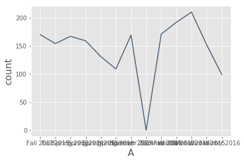

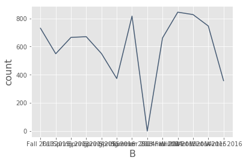

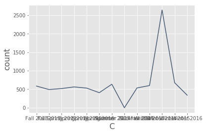

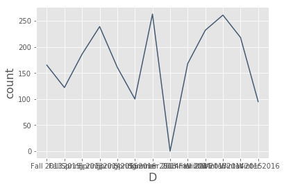

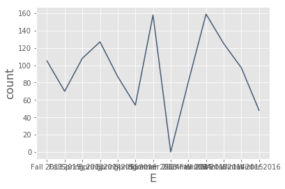

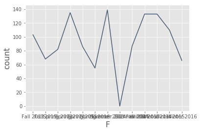

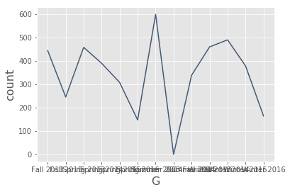

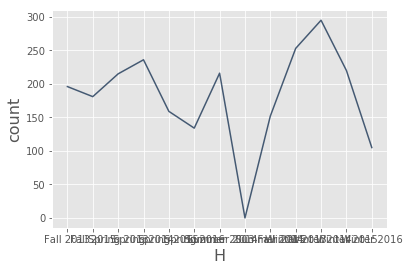

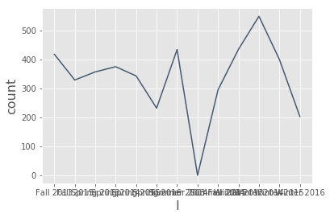

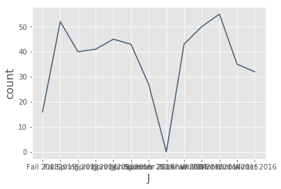

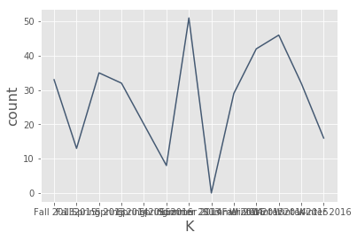

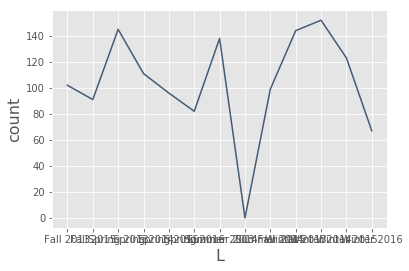

[9 more figures not shown]

```python
seasons = ['Winter 2013', 'Spring 2013', 'Summer 2013', 'Fall 2013', 'Winter 2014', 'Spring 2014', 'Summer 2014'
          'Fall 2014', 'Winter 2015', 'Spring 2015', 'Summer 2015', 'Fall 2015', 'Winter 2016', 'Spring 2016']

for season in list('ABCDEFGHIJKLMNOPQRSTU'):
    season_txns = seasons_by_yr.where('region', season)

    s2 = Table().with_columns('season', [], 'count', [])
    for i in seasons:
        s1 = season_txns.where('season', i).num_rows
        s2 = s2.with_row([i, s1])

    s2.plot('season')
    plt.xlabel(season)
```

## Conclusions

I concluded in my report that the business was deteriorating, but that there was a slight glimmer of hope. I will leave off with a quote from my report, summarizing what I thought of the trends:

> The slight rise in transaction volume and gross revenue between Winter 2016 and Spring 2016 could be an indication that the business might be beginning to right itself, especially given the fact that there is incomplete data for Spring 2016, since more data could only raise the transaction volume and would also likely raise the gross revenue. Depending on how risky an investment the firm is willing to tolerate, this business could potentially bring itself back to the level it was at previously, if it manages to maintain the (albeit short) trend that might be beginning to arise in Spring 2016.